# Project 0 EDA

Plot distribution of the difference between booklet sampling time and cap sampling time

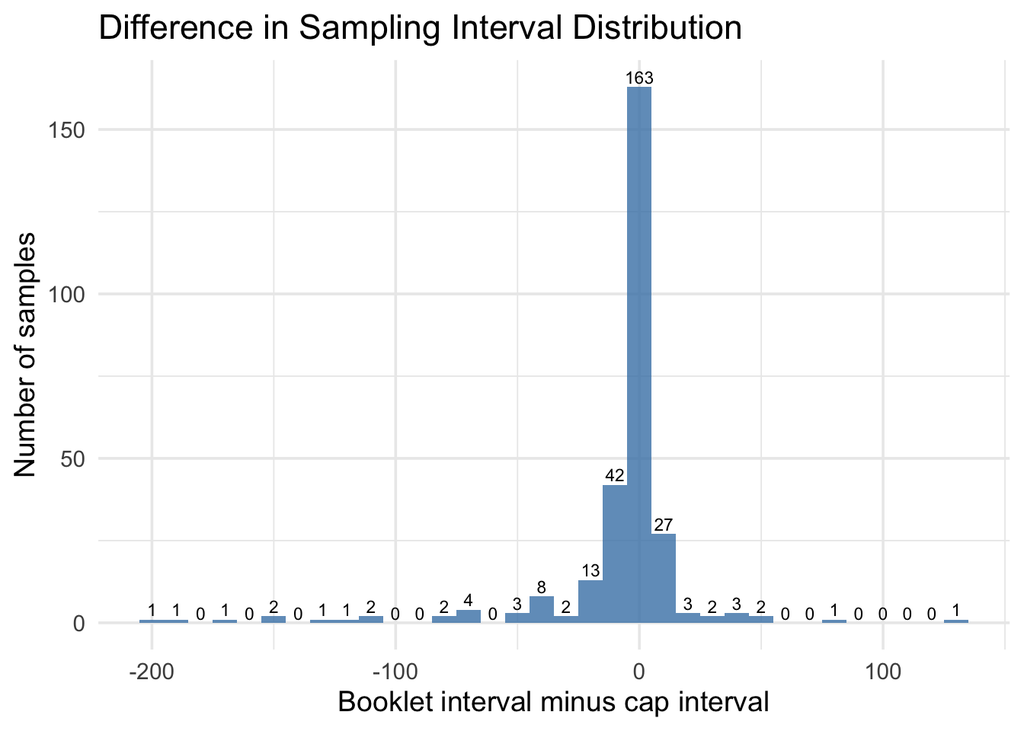

```r
ggplot(df_q1,
       aes(booklet_cap_difference)) +
  geom_histogram(binwidth = 10, fill = "steelblue", alpha = 0.8) +
  geom_text(
    stat = "bin",
    binwidth = 10,
    aes(label = after_stat(count)),
    vjust = -0.3,
    size = 3
  ) +
  theme_minimal(base_size = 14) +
  labs(
    x = "Booklet interval minus cap interval",
    y = "Number of samples",
    title = "Difference in Sampling Interval Distribution"
  )
```

Booklet and Cap Time fall pretty close together with some extreme outliers representing large differences between recorded booklet time and cap time.

Comparing booklet and electric monitoring cap using a mixed model:

```r
q1.lmm <- lmer(booklet_interval_mins ~ cap_interval_mins + (1|SubjectID),
               data = df_q1)
summary(q1.lmm)
```

```
## Linear mixed model fit by REML. t-tests use Satterthwaite's method [
## lmerModLmerTest]
## Formula: booklet_interval_mins ~ cap_interval_mins + (1 | SubjectID)
##    Data: df_q1
##
## REML criterion at convergence: 2787.7
##
## Scaled residuals:
##     Min      1Q  Median      3Q     Max
## -5.9420  0.0024  0.1588  0.2635  4.3866
##
## Random effects:
##  Groups    Name        Variance Std.Dev.
##  SubjectID (Intercept)  44.11    6.642
##  Residual              989.60   31.458
## Number of obs: 285, groups:  SubjectID, 31
##
## Fixed effects:
##                    Estimate Std. Error        df t value Pr(>|t|)
## (Intercept)        -6.50779    2.91608  66.29918  -2.232    0.029 *
## cap_interval_mins   0.99494    0.00706 262.91666 140.931   <2e-16 ***
## ---
## Signif. codes:  0 '***' 0.001 '**' 0.01 '*' 0.05 '.' 0.1 ' ' 1
##
## Correlation of Fixed Effects:
##             (Intr)
## cp_ntrvl_mn -0.641
```

```r
confint(q1.lmm)
```

```
## Computing profile confidence intervals ...
```

```
##                         2.5 %     97.5 %
## .sig01              0.0000000 12.2740368
## .sigma             28.8548052 34.3503012
## (Intercept)       -12.2587408 -0.7985482
## cap_interval_mins   0.9810298  1.0087634
```

For every 1 minute increase in recorded cap time, recorded booklet time increases by 0.995 minutes (95% CI: 0.981, 1.008, p-value: <0.0001). This suggests there is strong agreement between recorded cap time and recorded booklet time. The intercept suggests there is bias though, subjects recorded sample collection in their booklet about 6.508 (95% CI: -12.259, -0.799, p-value: 0.029) minutes earlier than recorded sample collection by the electronic cap.

Visualizing fit

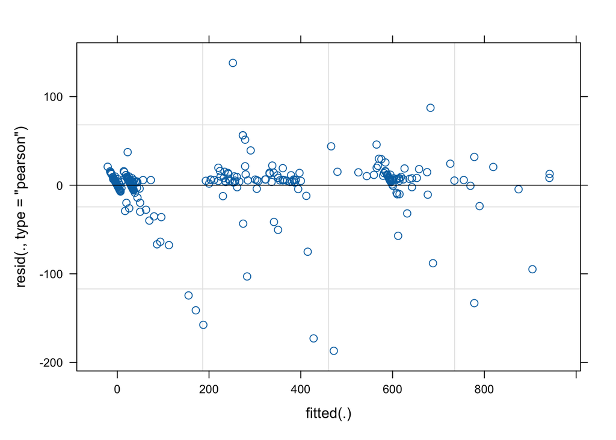

```r
plot(q1.lmm)
```

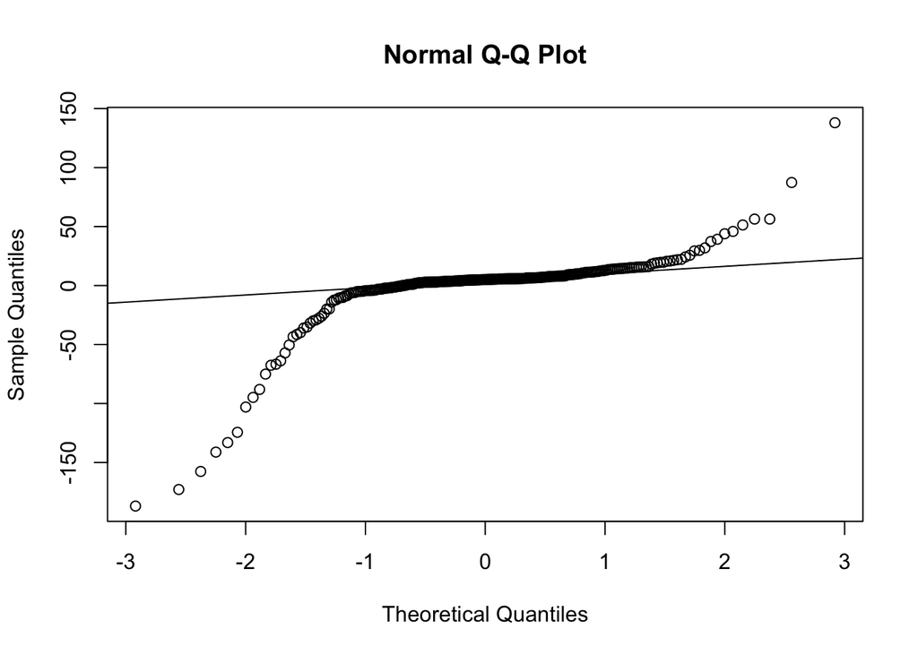

```r
qqnorm(residuals(q1.lmm))
qqline(residuals(q1.lmm))
```

The residuals are fairly close to 0 for most of the fitted values but there are a few observations with very large negative residuals. The qqplot shows the model is doing a good job fitting the majority of the data but there is strong deviation in the tails with some large negative and positive values.

Visualizing fitted vs observed values with identity line and fitted line

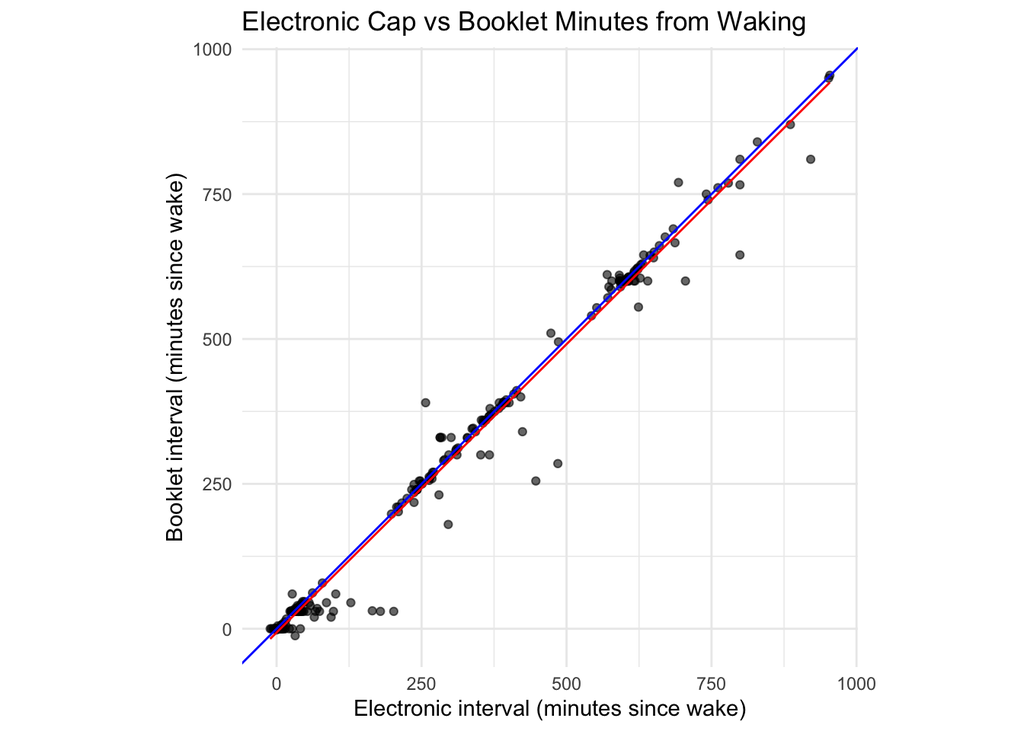

```r
pred_q1 <- tibble(
  cap_interval_mins = seq(min(df_q1$cap_interval_mins, na.rm = TRUE),
                          max(df_q1$cap_interval_mins, na.rm = TRUE),
                          length.out = 200)
)

pred_q1$booklet_pred <- predict(q1.lmm, newdata = pred_q1, re.form = NA)

ggplot(df_q1, aes(x = cap_interval_mins, y = booklet_interval_mins)) +
  geom_point(alpha = 0.6) +
  geom_line(
    data = pred_q1,
    aes(x = cap_interval_mins, y = booklet_pred),
    inherit.aes = FALSE,
    color = "red"
  ) +
  labs(
    x = "Electronic interval (minutes since wake)",
    y = "Booklet interval (minutes since wake)",
    title = "Electronic Cap vs Booklet Minutes from Waking"
  ) +
  geom_abline(slope = 1, intercept = 0, color = "blue") +
  theme_minimal() +
  coord_equal()
```

Question 2: Are subjects adhering accurately to the +30 min and +10 hour sampling times required by a protocol?

Adherence window 30 minutes (Collection 2) and 10 hours (Collection 4) after waking One analysis for good adherence = 7.5 minutes before or after (inclusive) - proportion of those who met this One analysis for adequate adherence = 15 minutes before or after (inclusive) - proportion of those who met this #Create collection time var to grab samples we’re interested in and booklet and cap deviation times from those collection windows

```r
df_q2 <- filter(df_mod, Collection.Sample %in% c("2","4"))

df_q2 <- df_q2 %>%
  mutate(
    cap_good = case_when(
      Collection.Sample == "2" ~ between(cap_interval_mins, 22.5, 37.5),
      Collection.Sample == "4" ~ between(cap_interval_mins, 592.5, 607.5),
      TRUE ~ NA
    ),

    cap_adequate = case_when(
      Collection.Sample == "2" ~ between(cap_interval_mins, 15, 45),
      Collection.Sample == "4" ~ between(cap_interval_mins, 585, 615),
      TRUE ~ NA
    ),

    booklet_good = case_when(
      Collection.Sample == "2" ~ between(booklet_interval_mins, 22.5, 37.5),
      Collection.Sample == "4" ~ between(booklet_interval_mins, 592.5, 607.5),
      TRUE ~ NA
    ),

    booklet_adequate = case_when(
      Collection.Sample == "2" ~ between(booklet_interval_mins, 15, 45),
      Collection.Sample == "4" ~ between(booklet_interval_mins, 585, 615),
      TRUE ~ NA
    )
  )
```

Tracking adherence

```r
adherence_summary <- df_q2 %>%
  group_by(Collection.Sample) %>%
  summarise(
    N = n(),

    #cap
    cap_good_n = sum(cap_good == TRUE, na.rm = TRUE),
    cap_adequate_n = sum(cap_adequate == TRUE, na.rm = TRUE),
    cap_missing_n = sum(is.na(cap_interval_mins)),

    #booklet
    booklet_good_n = sum(booklet_good == TRUE, na.rm = TRUE),
    booklet_adequate_n = sum(booklet_adequate == TRUE, na.rm = TRUE),
    booklet_missing_n = sum(is.na(booklet_interval_mins)),

    .groups = "drop"
  ) %>%
  mutate(
    cap_good_pct = round(100 * cap_good_n / (N - cap_missing_n), 1),
    cap_adequate_pct = round(100 * cap_adequate_n / (N - cap_missing_n), 1),

    booklet_good_pct = round(100 * booklet_good_n / (N - booklet_missing_n), 1),
    booklet_adequate_pct = round(100 * booklet_adequate_n / (N - booklet_missing_n), 1)
  )

#Create a tidy table for report/presentation
adherence_table <- adherence_summary %>%
  mutate(Collection.Sample = recode(Collection.Sample,
                                    "2" = "30 min",
                                    "4" = "10 hr")) %>%
  rename(
    `Sample Time` = Collection.Sample,
    `N` = N,
    `Cap Missing (n)` = cap_missing_n,
    `Booklet Missing (n)` = booklet_missing_n,
    `Cap Sample Good Adherence (%)` = cap_good_pct,
    `Cap Sample Adequate Adherence (%)` = cap_adequate_pct,
    `Booklet Sample Good Adherence (%)` = booklet_good_pct,
    `Booklet Sample Adequate Adherence (%)` = booklet_adequate_pct
  ) %>%
  dplyr::select(
    `Sample Time`,
    `N`,
    `Cap Missing (n)`,
    `Cap Sample Good Adherence (%)`,
    `Cap Sample Adequate Adherence (%)`,
    `Booklet Missing (n)`,
    `Booklet Sample Good Adherence (%)`,
    `Booklet Sample Adequate Adherence (%)`
  )

kable(adherence_table, caption = "Cap and Booklet Adherence by Collection Sample")
```

Cap and Booklet Adherence by Collection Sample

| Sample Time | N | Cap Missing (n) | Cap Sample Good Adherence (%) | Cap Sample Adequate Adherence (%) | Booklet Missing (n) | Booklet Sample Good Adherence (%) | Booklet Sample Adequate Adherence (%) |
| --- | --- | --- | --- | --- | --- | --- | --- |
| 30 min | 93 | 23 | 52.9 | 71.4 | 6 | 78.2 | 89.7 |
| 10 hr | 93 | 10 | 32.5 | 39.8 | 13 | 46.2 | 56.2 |

Calculate deviation (minutes) by sample for visualization

```r
df_q2 <- df_q2 %>%
  mutate(
    target_mins = case_when(
      Collection.Sample == "2" ~ 30,
      Collection.Sample == "4" ~ 60*10,
      TRUE ~ NA_real_
    ),
    cap_dev_mins = cap_interval_mins - target_mins,
    booklet_dev_mins = booklet_interval_mins - target_mins
  )
```

Cap Adherence Deviation Visualization

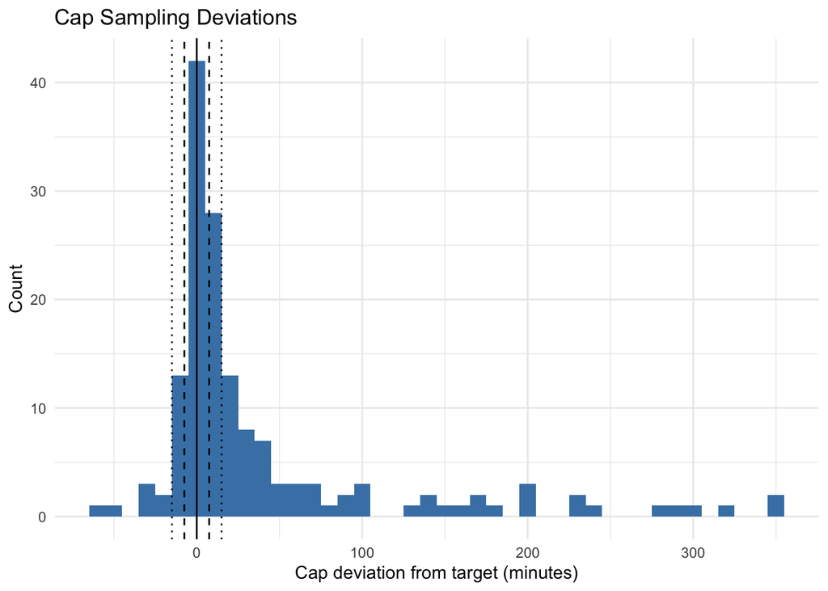

```r
ggplot(df_q2 %>% filter(!is.na(cap_dev_mins)),
       aes(x = cap_dev_mins)) +
  geom_histogram(binwidth = 10, fill = "steelblue") +
  geom_vline(xintercept = 0) +
  geom_vline(xintercept = c(-7.5, 7.5), linetype = "dashed") +
  geom_vline(xintercept = c(-15, 15), linetype = "dotted") +
  theme_minimal() +
  labs(
    x = "Cap deviation from target (minutes)",
    y = "Count",
    title = "Cap Sampling Deviations"
  )
```

Booklet Adherence Deviation

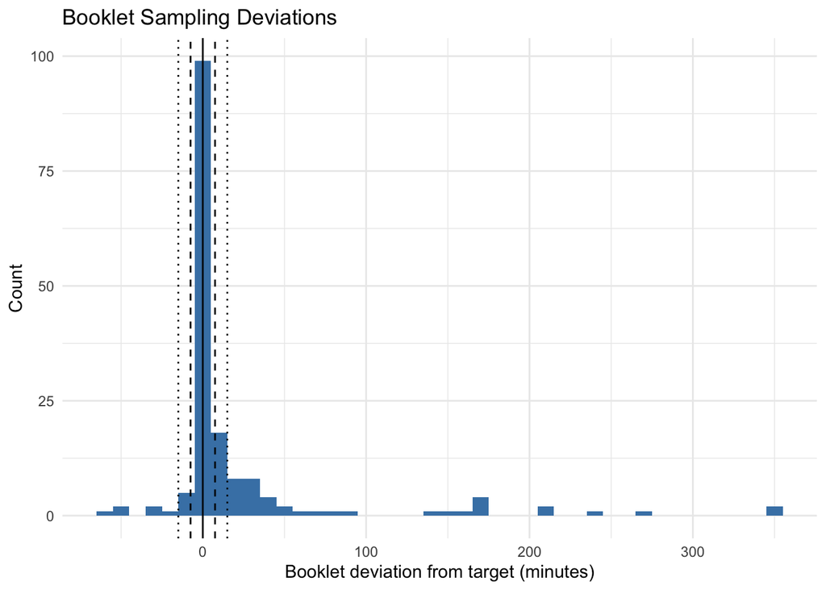

```r
ggplot(df_q2 %>% filter(!is.na(booklet_dev_mins)),
       aes(x = booklet_dev_mins)) +
  geom_histogram(binwidth = 10, fill = "steelblue") +
  geom_vline(xintercept = 0) +
  geom_vline(xintercept = c(-7.5, 7.5), linetype = "dashed") +
  geom_vline(xintercept = c(-15, 15), linetype = "dotted") +
  theme_minimal() +
  labs(
    x = "Booklet deviation from target (minutes)",
    y = "Count",
    title = "Booklet Sampling Deviations"
  )
```

Let’s see whether cap deviations vary by sample:

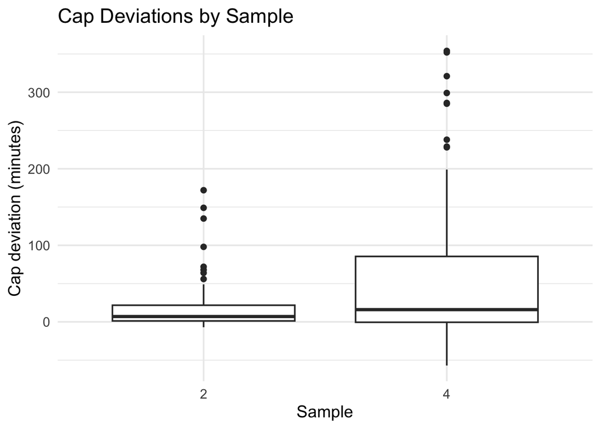

```r
ggplot(df_q2 %>% filter(!is.na(cap_dev_mins)),
       aes(factor(Collection.Sample), cap_dev_mins)) +
  geom_boxplot() +
  theme_minimal(base_size = 14) +
  labs(
    x = "Sample",
    y = "Cap deviation (minutes)",
    title = "Cap Deviations by Sample"
  )
```

Let’s see whether bookletdeviations vary by sample:

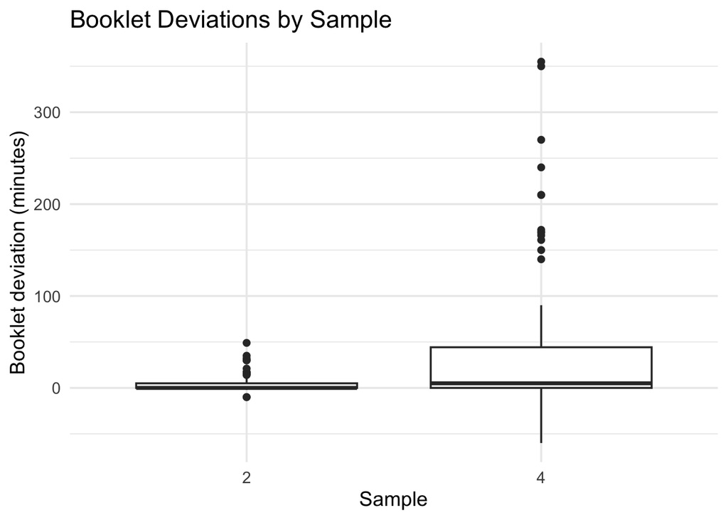

```r
ggplot(df_q2 %>% filter(!is.na(booklet_dev_mins)),
       aes(factor(Collection.Sample), booklet_dev_mins)) +
  geom_boxplot() +
  theme_minimal(base_size = 14) +
  labs(
    x = "Sample",
    y = "Booklet deviation (minutes)",
    title = "Booklet Deviations by Sample"
  )
```

Visualize cap and booklet times together

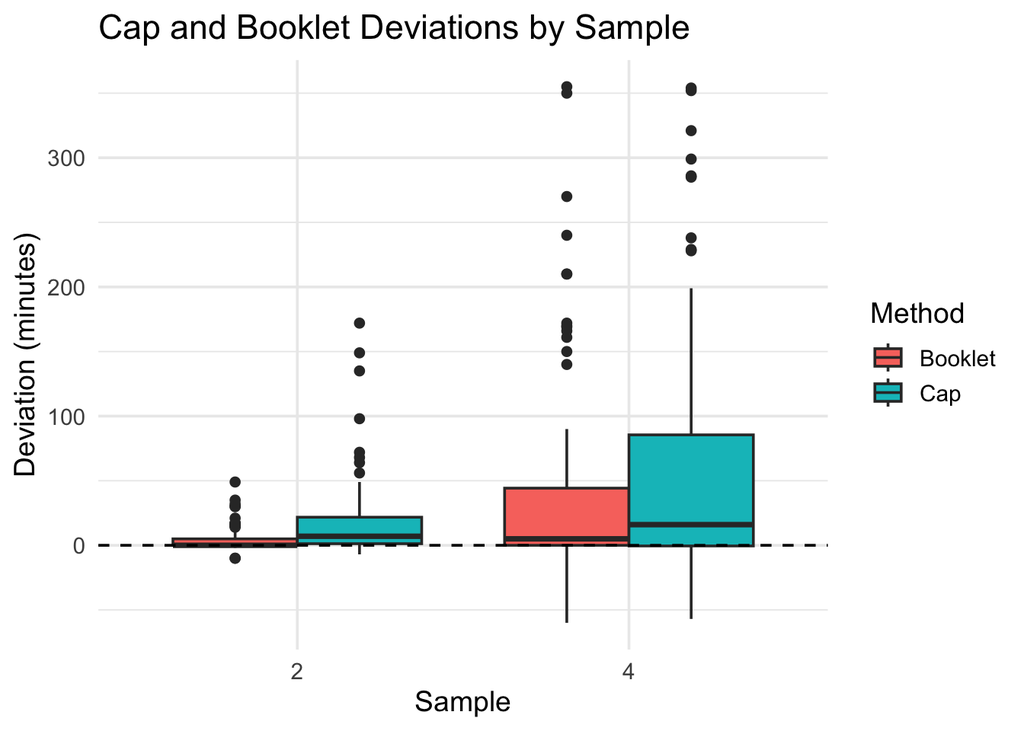

```r
dfq2_long <- df_q2 %>%
  pivot_longer(
    cols = c(cap_dev_mins, booklet_dev_mins),
    names_to = "method",
    values_to = "dev_mins"
  ) %>%
  filter(!is.na(dev_mins)) %>%
  mutate(
    method = recode(method,
                    cap_dev_mins = "Cap",
                    booklet_dev_mins = "Booklet"),
    Collection.Sample = factor(Collection.Sample)
  )

ggplot(dfq2_long, aes(Collection.Sample, dev_mins, fill = method)) +
  geom_boxplot(position = position_dodge(width = 0.75)) +
  geom_hline(yintercept = 0, linetype = "dashed") +
  theme_minimal(base_size = 14) +
  labs(
    x = "Sample",
    y = "Deviation (minutes)",
    title = "Cap and Booklet Deviations by Sample",
    fill = "Method"
  )
```

Question 3: What are the patterns of change over the course of the day? What is the investigator interested in knowing about changes over time? The investigator stated that levels of cortisol are expected to increase sharply from waking to 30 minutes after waking and then decline more slowly over the rest of the day.

She was interested in knowing if the SPIT test shows this expected pattern.

She wanted to know: 1) is there an increase in cortisol and/or DHEA from waking to 30 minutes post waking? And 2) what is the rate of decline in cortisol and DHEA after 30 minutes from waking?

She also stated that even if there are not statistically significant differences, she would like to know the estimates for the initial increase and rates of decline so she can compare them to what is known from other more standard hormone tests.

Biological Range of Data Cortisol > 26 keep but weird, Cortisol > 80 incorrect - probably a laboratory error DHEA upper limit on assay is 5.205 (max value in dataset - exclude these) - probably an error unless this is recorded repeatedly by the same individual (probably exclude these individuals bc they have a different process going on)

Outliers: Check no cortisol > 80, check no DHEA >5.205

```r
#One outlier with cortisol value > 80 - remove this
df_q3 <- filter(df_mod, Cortisol..nmol.L. < 80)

#DHEA investigation of upper limit lab values
x <- filter(df_q3,DHEA..nmol.L. == 5.205)

#SubjectID 3037 needs to be be removed as it is at the upper limit multiple times, suggesting something is wrong with this patient
df_q3 <- filter(df_q3, SubjectID != 3037)
```

Visualization of Subject 3024 strange behavior - overall this is fine, we’ll leave it in the analysis

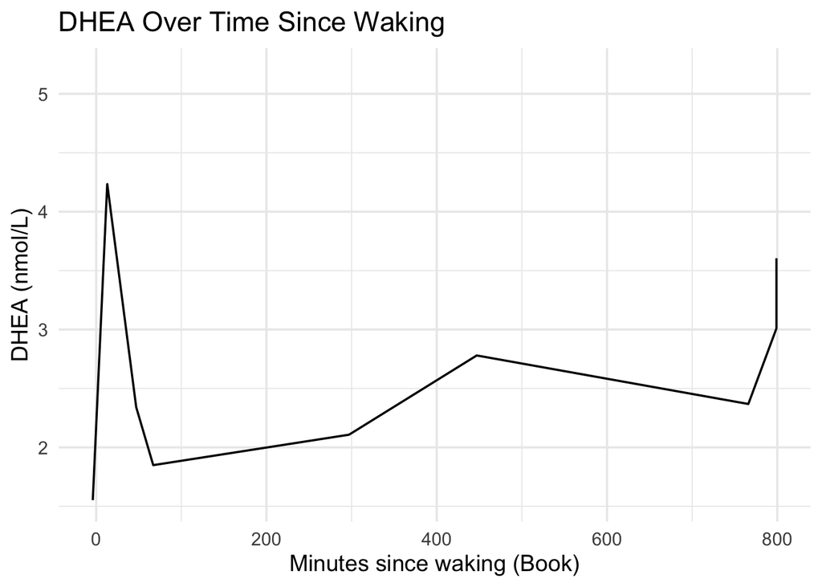

```r
ggplot((df_q3 %>% filter(SubjectID == 3024)), aes(x = cap_interval_mins, y = DHEA..nmol.L.)) +
  geom_line() +
  theme_minimal(base_size = 14) +
  labs(
    x = "Minutes since waking (Book)",
    y = "DHEA (nmol/L)",
    title = "DHEA Over Time Since Waking"
  )
```

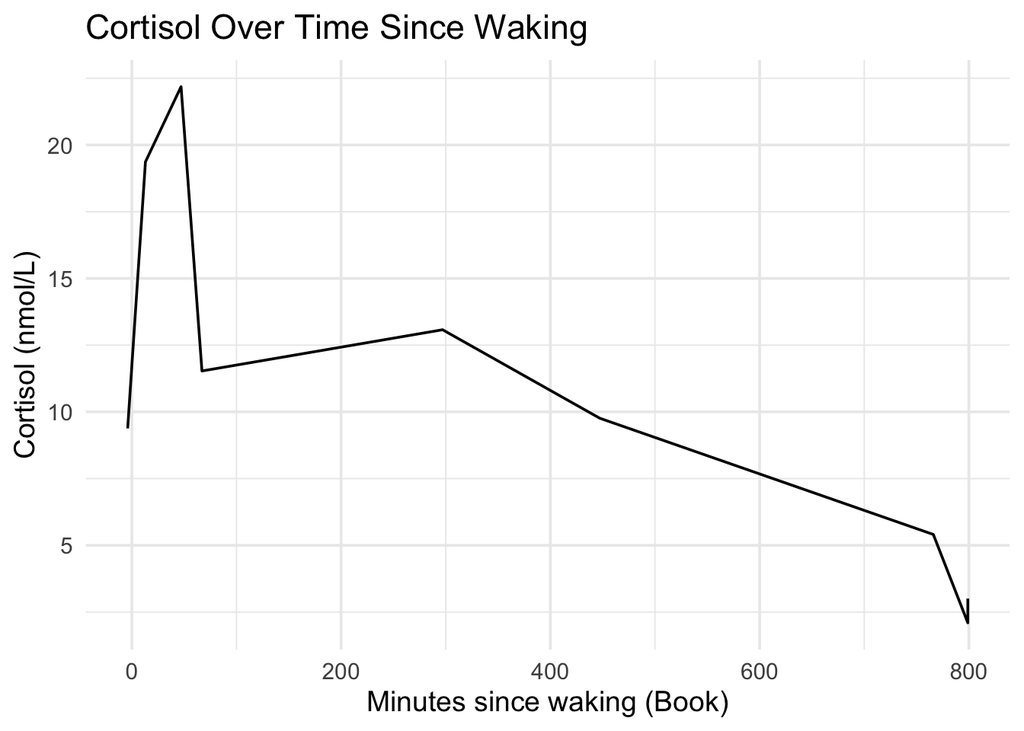

```r
ggplot((df_q3 %>% filter(SubjectID == 3024)), aes(x = cap_interval_mins, y = Cortisol..nmol.L.)) +
  geom_line() +
  theme_minimal(base_size = 14) +
  labs(
    x = "Minutes since waking (Book)",
    y = "Cortisol (nmol/L)",
    title = "Cortisol Over Time Since Waking"
  )
```

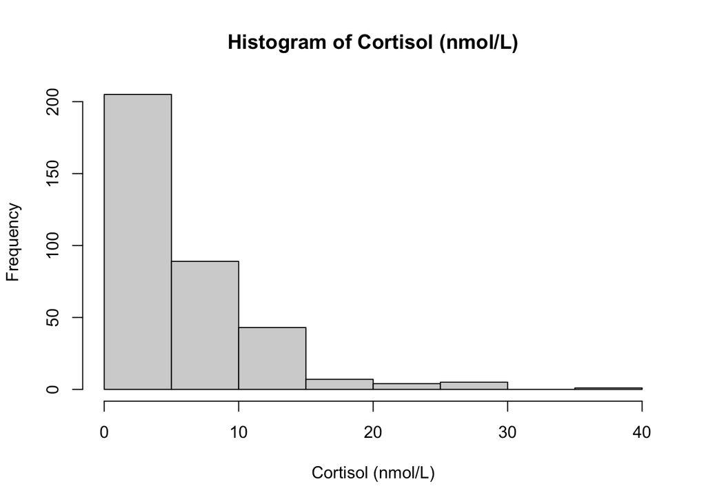

```r
#Visualize cortisol
hist(df_q3$Cortisol..nmol.L., main = "Histogram of Cortisol (nmol/L)", xlab = "Cortisol (nmol/L)")
```

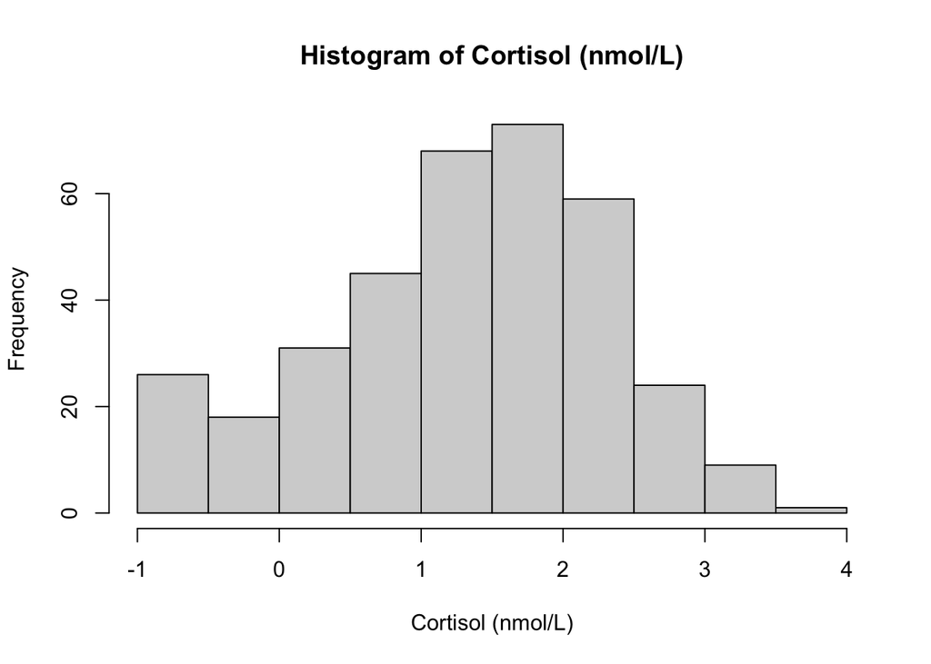

```r
#Heavy right skew - let's look at a log transformation
hist(log(df_q3$Cortisol..nmol.L.), main = "Histogram of Cortisol (nmol/L)", xlab = "Cortisol (nmol/L)")
```

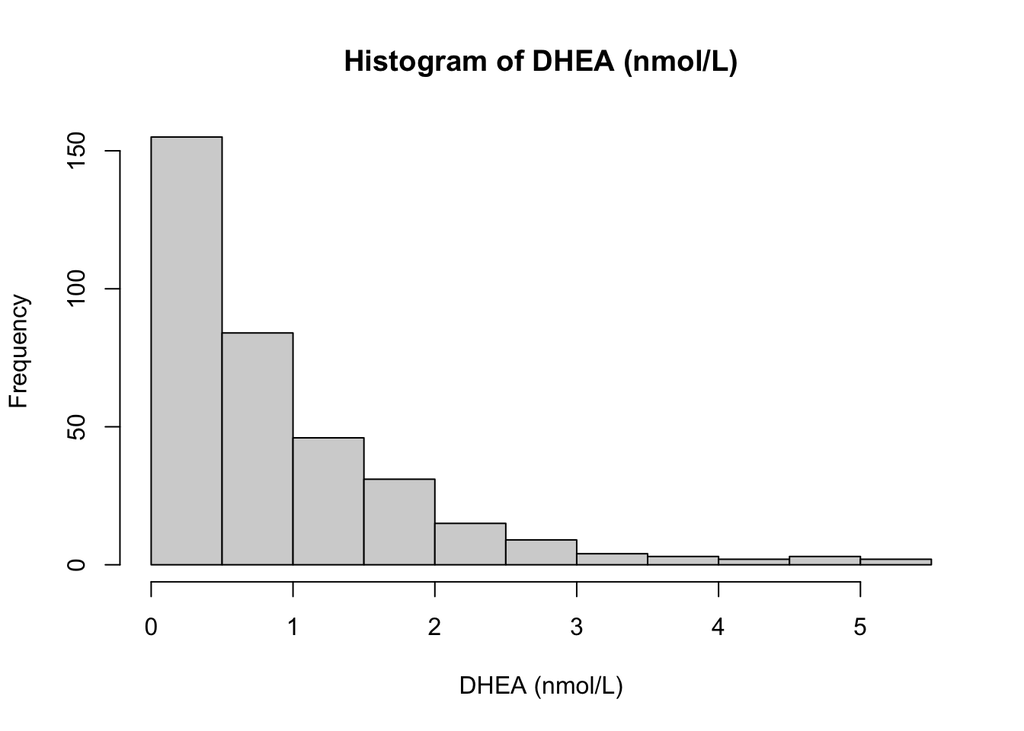

```r
#Visualizing DHEA
hist(df_q3$DHEA..nmol.L., main = "Histogram of DHEA (nmol/L)", xlab = "DHEA (nmol/L)")
```

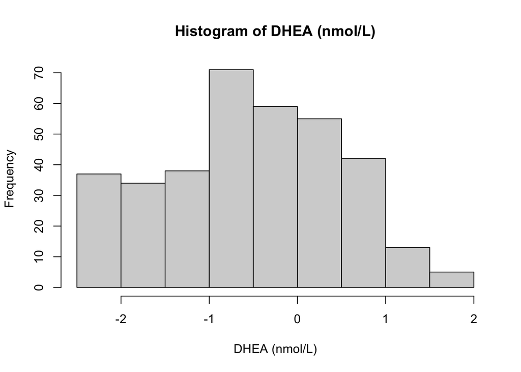

```r
#Again heavy right skew - let's look at the log transform
hist(log(df_q3$DHEA..nmol.L.),  main = "Histogram of DHEA (nmol/L)", xlab = "DHEA (nmol/L)")
```

```r
summary(df_q3$DHEA..nmol.L.)
```

```
##    Min. 1st Qu.  Median    Mean 3rd Qu.    Max.
##  0.1076  0.2991  0.5784  0.9224  1.2397  5.2050
```

```r
summary(df_q3$Cortisol..nmol.L.)
```

```
##    Min. 1st Qu.  Median    Mean 3rd Qu.    Max.
##  0.5242  2.0486  4.1109  5.6825  7.6217 37.6879
```

Significant outlier of 37, leaving it in the analysis but noting it’s strange

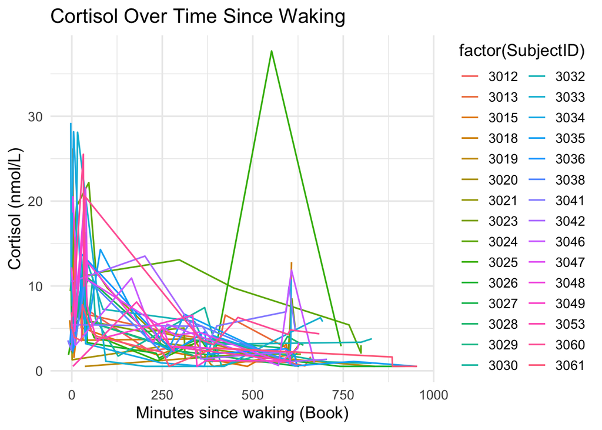

```r
ggplot(df_q3, aes(x = cap_interval_mins, y = Cortisol..nmol.L., group = SubjectID, color = factor(SubjectID))) +
  geom_line() +
  theme_minimal(base_size = 14) +
  labs(
    x = "Minutes since waking (Book)",
    y = "Cortisol (nmol/L)",
    title = "Cortisol Over Time Since Waking"
  )
```

Zoom in to verify peak cortisol is where we expect

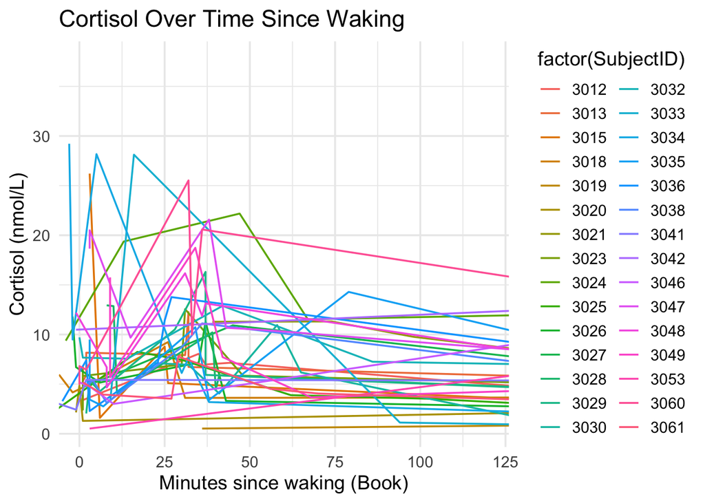

```r
ggplot(df_q3, aes(x = cap_interval_mins, y = Cortisol..nmol.L., group = SubjectID, color = factor(SubjectID))) +
  geom_line() +
  theme_minimal(base_size = 14) +
  labs(
    x = "Minutes since waking (Book)",
    y = "Cortisol (nmol/L)",
    title = "Cortisol Over Time Since Waking"
  )+
  coord_cartesian(xlim = c(0, 120))
```

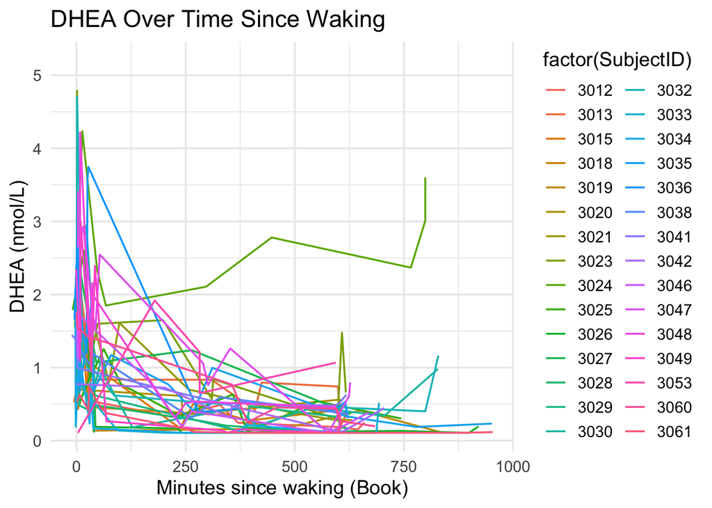

```r
ggplot(df_q3, aes(x = cap_interval_mins, y = DHEA..nmol.L., group = SubjectID, color = factor(SubjectID))) +
  geom_line() +
  theme_minimal(base_size = 14) +
  labs(
    x = "Minutes since waking (Book)",
    y = "DHEA (nmol/L)",
    title = "DHEA Over Time Since Waking"
  )
```

Let’s see if DHEA even needs a changepoint like cortisol

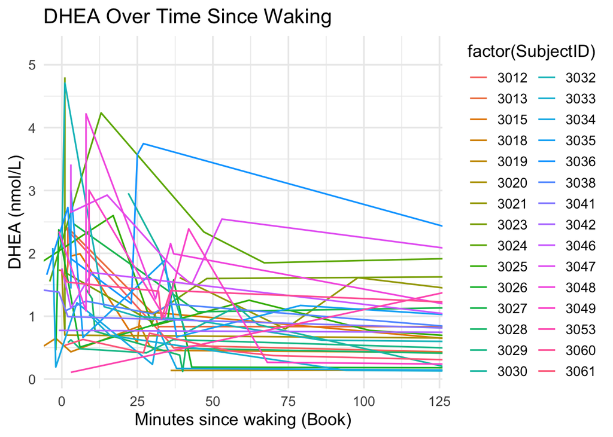

```r
ggplot(df_q3, aes(x = cap_interval_mins, y = DHEA..nmol.L., group = SubjectID, color = factor(SubjectID))) +
  geom_line() +
  theme_minimal(base_size = 14) +
  labs(
    x = "Minutes since waking (Book)",
    y = "DHEA (nmol/L)",
    title = "DHEA Over Time Since Waking"
  ) +
  coord_cartesian(xlim = c(0, 120))
```

Changepoint at 30 might not make sense let’s investigate further

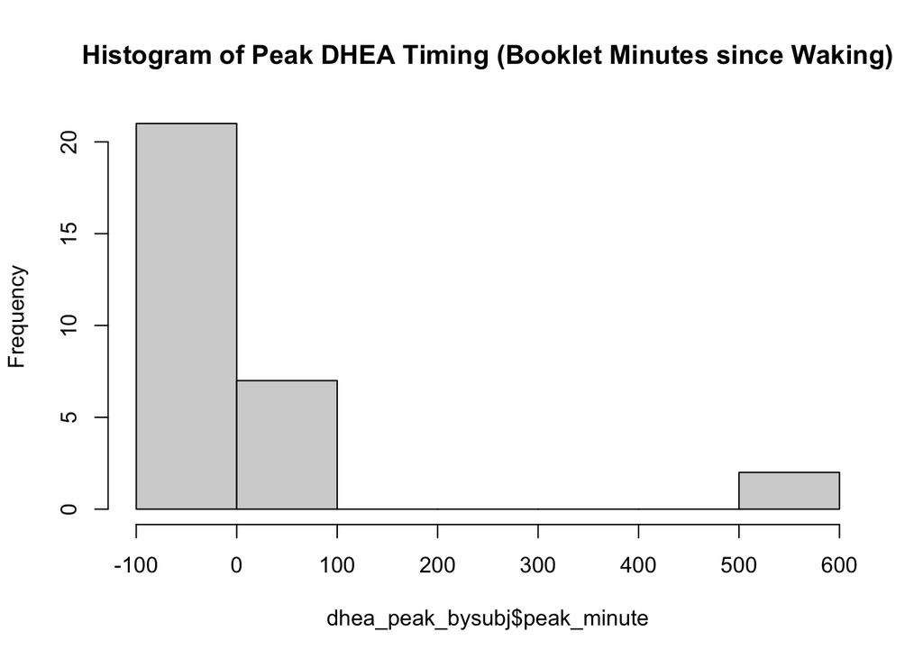

```r
dhea_peak_bysubj <- df_q3 %>%
  filter(!is.na(DHEA..nmol.L.), !is.na(booklet_interval_mins)) %>%
  group_by(SubjectID) %>%
  slice_max(DHEA..nmol.L., with_ties = FALSE) %>%
  summarise(
    peak_minute = booklet_interval_mins,
    peak_dhea = DHEA..nmol.L.,
    .groups = "drop"
  )
dhea_peak_by_subj_day <- df_q3 %>%
  filter(!is.na(DHEA..nmol.L.), !is.na(booklet_interval_mins), !is.na(DAYNUMB)) %>%
  group_by(SubjectID, DAYNUMB) %>%
  arrange(desc(DHEA..nmol.L.), booklet_interval_mins) %>%  # highest DHEA, then earliest time
  slice(1) %>%
  ungroup() %>%
  transmute(
    SubjectID,
    DAYNUMB,
    peak_minute = booklet_interval_mins,
    peak_dhea   = DHEA..nmol.L.
  )


hist(dhea_peak_bysubj$peak_minute, main = "Histogram of Peak DHEA Timing (Booklet Minutes since Waking)")
```

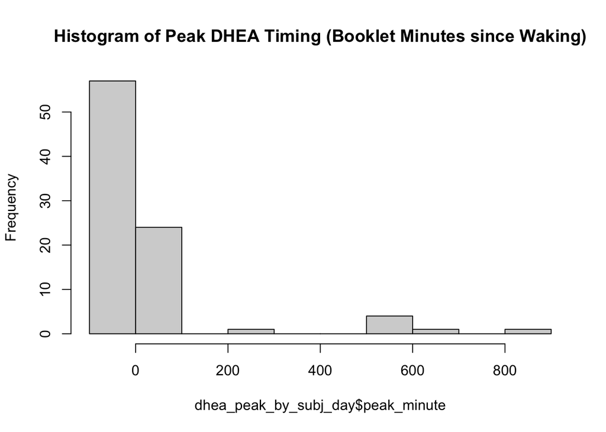

```r
hist(dhea_peak_by_subj_day$peak_minute, main = "Histogram of Peak DHEA Timing (Booklet Minutes since Waking)")
```

Create variable for 30 minute knot and let’s proceed with logging DHEA and Cortisol

```r
#Let's verify knot - 34 mins is our mean but the literature suggests 30 minutes so let's stick with that
mean(
  df_q3 %>%
    filter(Collection.Sample == "2") %>%
    pull(booklet_interval_mins),
  na.rm = TRUE
)
```

```
## [1] 34.28571
```

```r
#Modified from BIOS 6643 code- changepoint creation
df_q3 <- df_q3 %>%
  mutate(
    wake_30 = pmin(booklet_interval_mins, 30),
    after_30 = pmax(booklet_interval_mins - 30, 0),
    log_cortisol = log(Cortisol..nmol.L.),
    log_dhea = log(DHEA..nmol.L.)
  )
```

```r
q3_cortisol.lmm <- lmer(
  log_cortisol ~ wake_30 + after_30 + (1 | SubjectID),
  data = df_q3
)

summary(q3_cortisol.lmm)
```

```
## Linear mixed model fit by REML. t-tests use Satterthwaite's method [
## lmerModLmerTest]
## Formula: log_cortisol ~ wake_30 + after_30 + (1 | SubjectID)
##    Data: df_q3
##
## REML criterion at convergence: 775.6
##
## Scaled residuals:
##     Min      1Q  Median      3Q     Max
## -3.1531 -0.5068  0.0402  0.5695  3.9510
##
## Random effects:
##  Groups    Name        Variance Std.Dev.
##  SubjectID (Intercept) 0.1147   0.3387
##  Residual              0.5352   0.7316
## Number of obs: 323, groups:  SubjectID, 30
##
## Fixed effects:
##               Estimate Std. Error         df t value Pr(>|t|)
## (Intercept)  1.684e+00  1.024e-01  9.086e+01  16.438   <2e-16 ***
## wake_30      6.134e-03  3.647e-03  2.912e+02   1.682   0.0936 .
## after_30    -2.231e-03  1.851e-04  2.944e+02 -12.052   <2e-16 ***
## ---
## Signif. codes:  0 '***' 0.001 '**' 0.01 '*' 0.05 '.' 0.1 ' ' 1
##
## Correlation of Fixed Effects:
##          (Intr) wak_30
## wake_30  -0.594
## after_30  0.003 -0.503
```

```r
cortisol_table <- tidy(q3_cortisol.lmm, effects = "fixed", conf.int = TRUE)
cortisol_table <- cortisol_table %>%
  mutate(
    estimate_exp = exp(estimate),
    conf.low_exp = exp(conf.low),
    conf.high_exp = exp(conf.high)
  )

cortisol_table_exp <- cortisol_table %>%
  dplyr::select(term, estimate_exp, conf.low_exp, conf.high_exp, p.value) %>%
  rename(
    Term = term,
    `Rate Ratio` = estimate_exp,
    `95% CI Lower` = conf.low_exp,
    `95% CI Upper` = conf.high_exp,
    `p-value` = p.value
  )
kable(cortisol_table_exp, digits = 3,
      caption = "Linear Mixed Model of Log Cortisol on Minutes Since Waking - Raw Estimates")
```

| Term | Rate Ratio | 95% CI Lower | 95% CI Upper | p-value |
| --- | --- | --- | --- | --- |
| (Intercept) | 5.387 | 4.395 | 6.603 | 0.000 |
| wake_30 | 1.006 | 0.999 | 1.013 | 0.094 |
| after_30 | 0.998 | 0.997 | 0.998 | 0.000 |

```r
kable(cortisol_table_exp, digits = 3,
      caption = "Linear Mixed Model of Log Cortisol on Minutes Since Waking - Transformed Estimates")
```

Linear Mixed Model of Log Cortisol on Minutes Since Waking - Transformed Estimates

| Term | Rate Ratio | 95% CI Lower | 95% CI Upper | p-value |
| --- | --- | --- | --- | --- |
| (Intercept) | 5.387 | 4.395 | 6.603 | 0.000 |
| wake_30 | 1.006 | 0.999 | 1.013 | 0.094 |
| after_30 | 0.998 | 0.997 | 0.998 | 0.000 |

```r
q3_dhea.lmm <- lmer(
  log_dhea ~ booklet_interval_mins + (1 | SubjectID),
  data = df_q3
)

summary(q3_dhea.lmm)
```

```
## Linear mixed model fit by REML. t-tests use Satterthwaite's method [
## lmerModLmerTest]
## Formula: log_dhea ~ booklet_interval_mins + (1 | SubjectID)
##    Data: df_q3
##
## REML criterion at convergence: 703.8
##
## Scaled residuals:
##     Min      1Q  Median      3Q     Max
## -4.1476 -0.5581 -0.0167  0.6450  2.5377
##
## Random effects:
##  Groups    Name        Variance Std.Dev.
##  SubjectID (Intercept) 0.2625   0.5123
##  Residual              0.4061   0.6372
## Number of obs: 323, groups:  SubjectID, 30
##
## Fixed effects:
##                         Estimate Std. Error         df t value Pr(>|t|)
## (Intercept)           -2.856e-02  1.059e-01  3.550e+01   -0.27    0.789
## booklet_interval_mins -2.000e-03  1.362e-04  2.955e+02  -14.69   <2e-16 ***
## ---
## Signif. codes:  0 '***' 0.001 '**' 0.01 '*' 0.05 '.' 0.1 ' ' 1
##
## Correlation of Fixed Effects:
##             (Intr)
## bklt_ntrvl_ -0.314
```

Get results in an easy to read format

```r
dhea_table <- tidy(q3_dhea.lmm, effects = "fixed", conf.int = TRUE)
dhea_table <- dhea_table %>%
  mutate(
    estimate_exp = exp(estimate),
    conf.low_exp = exp(conf.low),
    conf.high_exp = exp(conf.high)
  )

dhea_table_exp <- dhea_table %>%
  dplyr::select(term, estimate_exp, conf.low_exp, conf.high_exp, p.value) %>%
  rename(
    Term = term,
    `Rate Ratio` = estimate_exp,
    `95% CI Lower` = conf.low_exp,
    `95% CI Upper` = conf.high_exp,
    `p-value` = p.value
  )

kable(dhea_table, digits = 3,
      caption = "Linear Mixed Model of Log DHEA on Minutes Since Waking - Raw Estimates")
```

Linear Mixed Model of Log DHEA on Minutes Since Waking - Raw Estimates

| effect | term | estimate | std.error | statistic | df | p.value | conf.low | conf.high | estimate_exp | conf.low_exp | conf.high_exp |
| --- | --- | --- | --- | --- | --- | --- | --- | --- | --- | --- | --- |
| fixed | (Intercept) | -0.029 | 0.106 | -0.27 | 35.505 | 0.789 | -0.243 | 0.186 | 0.972 | 0.784 | 1.205 |
| fixed | booklet_interval_mins | -0.002 | 0.000 | -14.69 | 295.508 | 0.000 | -0.002 | -0.002 | 0.998 | 0.998 | 0.998 |

```r
kable(dhea_table_exp, digits = 3,
      caption = "Linear Mixed Model of Log DHEA on Minutes Since Waking - Transformed Estimates")
```

Linear Mixed Model of Log DHEA on Minutes Since Waking - Transformed Estimates

| Term | Rate Ratio | 95% CI Lower | 95% CI Upper | p-value |
| --- | --- | --- | --- | --- |
| (Intercept) | 0.972 | 0.784 | 1.205 | 0.789 |
| booklet_interval_mins | 0.998 | 0.998 | 0.998 | 0.000 |

From resource on canvas: If this is a value great than 1, you can subtract 1 and multiply by 100 to get the % increase associated with a 1-unit increase in X1.

If this value is less than 1, you can subtract 1 and multiple by 100 to get the % decrease associated with a 1-unit increase in X1.

This means that exp(beta1) can be roughly interpreted as the percentage change in of Y with a one unit increase in X1.

Visualizing the fit of Cortisol

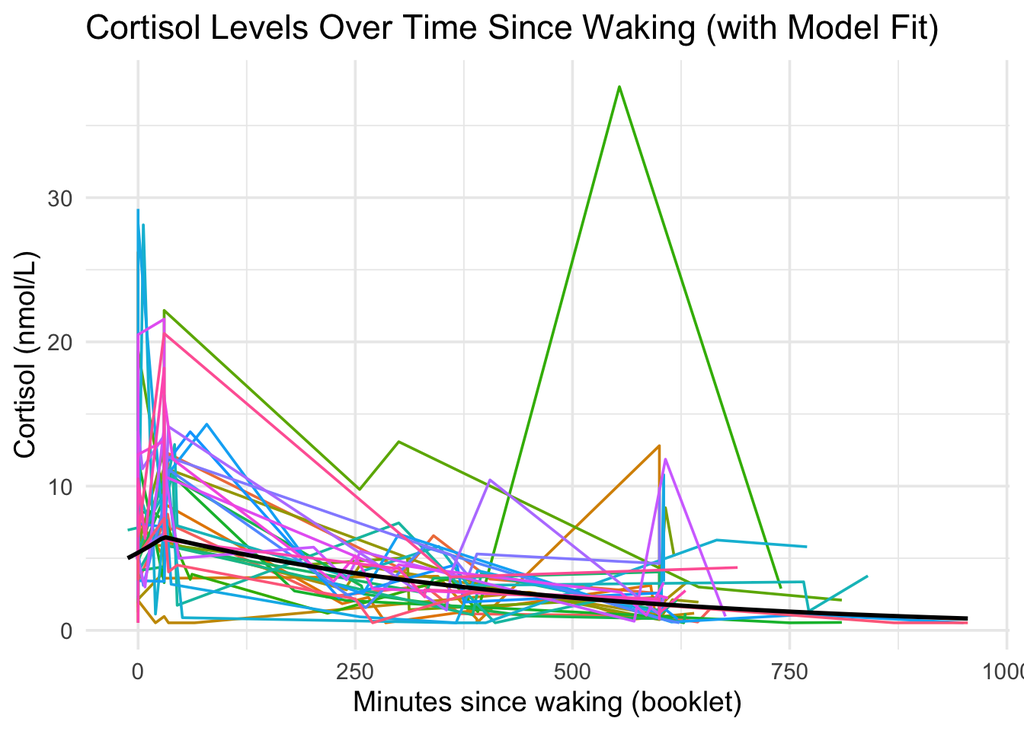

```r
pred_df <- tibble(
  booklet_interval_mins = seq(min(df_q3$booklet_interval_mins, na.rm = TRUE),
                          max(df_q3$booklet_interval_mins, na.rm = TRUE),
                          length.out = 200)
) %>%
  mutate(
    wake_30 = pmin(booklet_interval_mins, 30),
    after_30 = pmax(booklet_interval_mins - 30, 0)
  )

pred_df$pred_log_cort <- predict(q3_cortisol.lmm, newdata = pred_df, re.form = NA)

# Back-transform to nmol/L
pred_df$pred_cort <- exp(pred_df$pred_log_cort)

ggplot(df_q3,
       aes(x = booklet_interval_mins,
           y = Cortisol..nmol.L.,
           group = SubjectID,
           color = factor(SubjectID))) +
  geom_line() +
  geom_line(
    data = pred_df,
    aes(x = booklet_interval_mins, y = pred_cort),
    inherit.aes = FALSE,
    linewidth = 1,
    color = "black"
  ) +
  theme_minimal(base_size = 14) +
  theme(legend.position = "none") +
  labs(
    x = "Minutes since waking (booklet)",
    y = "Cortisol (nmol/L)",
    title = "Cortisol Levels Over Time Since Waking (with Model Fit)"
  )
```

Visualizing the fit of DHEA

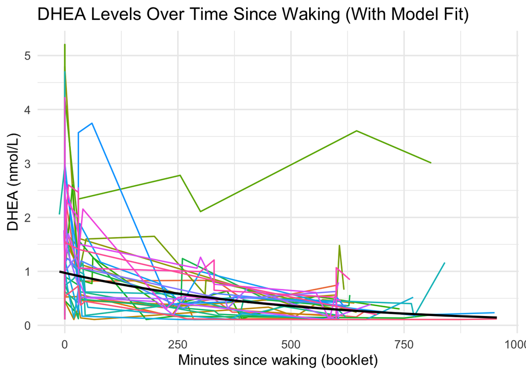

```r
pred_dhea <- tibble(
  booklet_interval_mins = seq(min(df_q3$booklet_interval_mins, na.rm = TRUE),
                              max(df_q3$booklet_interval_mins, na.rm = TRUE),
                              length.out = 200)
)

pred_dhea$pred_log_dhea <- predict(q3_dhea.lmm, newdata = pred_dhea, re.form = NA)

# Back-transform to nmol/L
pred_dhea$pred_dhea <- exp(pred_dhea$pred_log_dhea)

ggplot(df_q3,
       aes(x = booklet_interval_mins,
           y = DHEA..nmol.L.,
           group = SubjectID,
           color = factor(SubjectID))) +
  geom_line() +
  geom_line(
    data = pred_dhea,
    aes(x = booklet_interval_mins, y = pred_dhea),
    inherit.aes = FALSE,
    linewidth = 1,
    color = "black"
  ) +
  theme_minimal(base_size = 14) +
  theme(legend.position = "none") +
  labs(
    x = "Minutes since waking (booklet)",
    y = "DHEA (nmol/L)",
    title = "DHEA Levels Over Time Since Waking (With Model Fit)"
  )
```